# Distrubution and Scatterplot Analysis

Bugra

23/11/2022

## Distributions

This analysis shows the raw and normalised distribution of base earning, driven distance and delivery time for each delivery run.

```r
summary(uberdata[c('delivery_base_earning','distance','delivery_time_min')])
```

```
##  delivery_base_earning    distance      delivery_time_min
##  Min.   : 4.62         Min.   : 0.100   Min.   :  6.50
##  1st Qu.: 7.34         1st Qu.: 2.800   1st Qu.: 16.60
##  Median :10.36         Median : 5.100   Median : 24.47
##  Mean   :11.53         Mean   : 5.834   Mean   : 27.94
##  3rd Qu.:14.56         3rd Qu.: 7.900   3rd Qu.: 36.30
##  Max.   :36.87         Max.   :27.900   Max.   :103.00
```

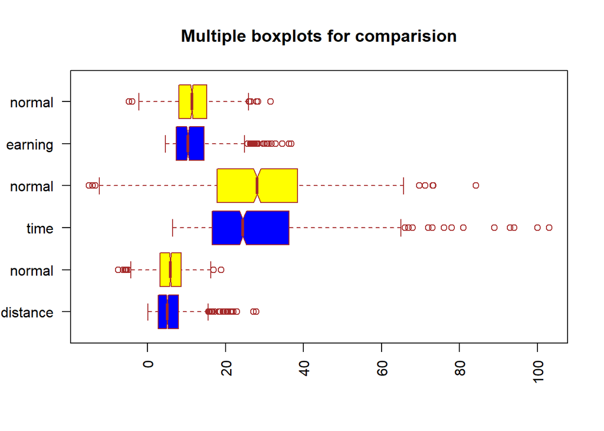

```r
# Data Preparation

dis<-uberdata$distance
time<-uberdata$delivery_time_min
earn<-uberdata$delivery_base_earning

# Normal Distribution
dis_norm <- rnorm(1300,mean = mean(dis,na.rm = TRUE), sd=sd(dis,na.rm = TRUE))
time_norm <- rnorm(1300,mean = mean(time,na.rm = TRUE), sd=sd(time,na.rm = TRUE))
earn_norm <- rnorm(1300,mean = mean(earn,na.rm = TRUE), sd=sd(earn,na.rm = TRUE))

#Visualisation

boxplot(dis, dis_norm, time, time_norm, earn, earn_norm,
main = "Multiple boxplots for comparision",
at = c(1,2,3,4,5,6),
names = c("distance", "normal", "time", "normal", "earning", "normal"),
las = 2,
col = c("blue","yellow"),
border = "brown",
horizontal = TRUE,
notch = TRUE)
```

Regarding the raw distribution it can be seen that each variable has a positively skewed distribution. As we normalize them, there is a negligible movement in quartiles, therefore we can proceed with the raw distribution.

## Distance vs. Earning Comparison

This analysis compares two major variables, where driven distance acts as an independent variable to base earnings.

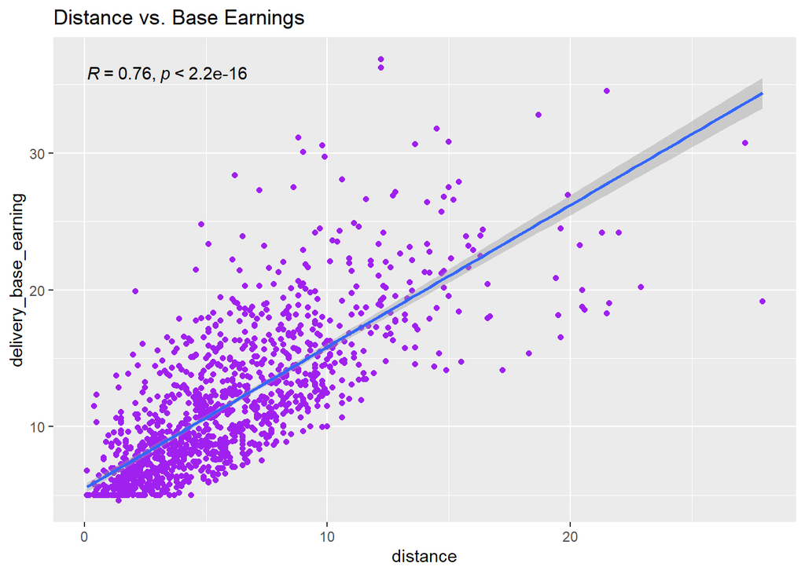

```r
ggplot(uberdata,aes(x= distance, y=delivery_base_earning))+
    geom_point(color = "Purple")+
    geom_smooth(method=lm)+
    stat_cor(method = "pearson")+
    labs(title ="Distance vs. Base Earnings")
```

## Delivery duration vs. Earning Comparison

This analysis compares other two major variables, where delivery duration acts as an independent variable to base earnings.

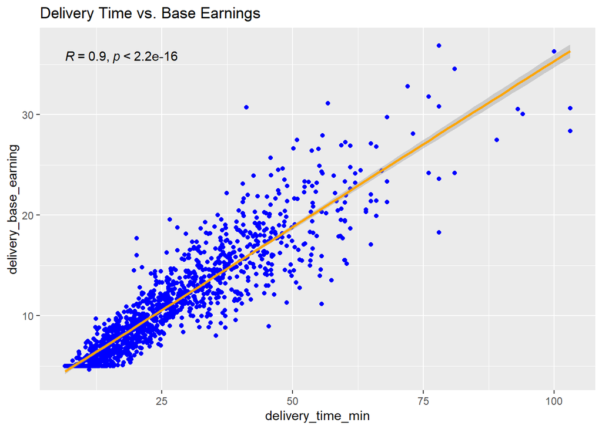

```r
  ggplot(uberdata,aes(x= delivery_time_min, y=delivery_base_earning)) +
  geom_point(color = "Blue")+
  geom_smooth(method=lm, color = "Orange")+
  stat_cor(method = "pearson")+
  labs(title ="Delivery Time vs. Base Earnings")
```

## Conclusion

Both variables, distance and time, have a significant positive correlation with base earning, which means as you drive longer in distance and time, it’s most likely to earn more money per delivery run. But despite the strong correlation, it can be deduced that time’s effect on earning is more explainable. It’s most likely to earn more as you spend more time on a single delivery rather than drive for more distance.